# Project: Investigate a Dataset - [Patients no-show clinical appointments]

## Introduction

### Dataset Description

> This dataset gathers data from 100,000 clinical arrangements in Brazil and is centered around whether patients appear for their arrangement. Various qualities about the patient are remembered for each column. See sections underneath

PatientID

AppointmentID

Gender

ScheduledDay - day the patient set up their appointment.

AppointmentDay - day the patient had the appointment.

Age

Neighborhood - indicates the location of the hospital.

Scholarship - indicates whether or not the patient is enrolled in Brasilian welfare program Bolsa Família.

Hipertension

Diabetes

Alcoholism

Handcap

SMS_received - '0' if they did not receive and '1' if they did.

No-show: 'No' if the patient showed up to their appointment, and 'Yes' if they did not show up.

### Question(s) for Analysis

> Questions for Analysis This Project will investigate and give bits of knowledge to the accompanying questions:
- What is the level of patients who went to their arrangements against the individuals who missed?
- Who do go to the doctor more often, males or females?
- Does the age of a patient influence their participation to arrangements?
- Which age is most affected by disease?
- Does receiving SMS reminder affect patients attendance to appointments?

```python
# Use this cell to set up import statements for all of the packages that you
#   plan to use.

# import packages
import pandas as pd
import numpy as np
import matplotlib.pyplot as plt
import seaborn as sns

# Remember to include a 'magic word' so that your visualizations are plotted
#   inline with the notebook. See this page for more:
#   http://ipython.readthedocs.io/en/stable/interactive/magics.html

%matplotlib inline
```

```python
# Upgrade pandas to use dataframe.explode() function.
!pip install --upgrade pandas==0.25.0
```

## Data Wrangling

> In this section, we will load in the data, check for cleanliness, and then trim and clean the dataset for analysis.

## General Properties

```python
# Load data
df = pd.read_csv('noshowappointments-kagglev2-may-2016.csv')

df.head()
```

|  | PatientId | AppointmentID | Gender | ScheduledDay | AppointmentDay | Age | Neighbourhood | Scholarship | Hipertension | Diabetes | Alcoholism | Handcap | SMS_received | No-show |
| --- | --- | --- | --- | --- | --- | --- | --- | --- | --- | --- | --- | --- | --- | --- |
| 0 | 2.990000e+13 | 5642903 | F | 2016-04-29T18:38:08Z | 2016-04-29T00:00:00Z | 62 | JARDIM DA PENHA | 0 | 1 | 0 | 0 | 0 | 0 | No |
| 1 | 5.590000e+14 | 5642503 | M | 2016-04-29T16:08:27Z | 2016-04-29T00:00:00Z | 56 | JARDIM DA PENHA | 0 | 0 | 0 | 0 | 0 | 0 | No |
| 2 | 4.260000e+12 | 5642549 | F | 2016-04-29T16:19:04Z | 2016-04-29T00:00:00Z | 62 | MATA DA PRAIA | 0 | 0 | 0 | 0 | 0 | 0 | No |
| 3 | 8.680000e+11 | 5642828 | F | 2016-04-29T17:29:31Z | 2016-04-29T00:00:00Z | 8 | PONTAL DE CAMBURI | 0 | 0 | 0 | 0 | 0 | 0 | No |
| 4 | 8.840000e+12 | 5642494 | F | 2016-04-29T16:07:23Z | 2016-04-29T00:00:00Z | 56 | JARDIM DA PENHA | 0 | 1 | 1 | 0 | 0 | 0 | No |

```python
df.shape
```

```
(110527, 14)
```

the dataframe size is 110527 rows with 14 columns

```python
#check for dupilicates
df.duplicated().sum()
```

```
0
```

There are no duplicates in our rows

```python
df.describe()
```

|  | PatientId | AppointmentID | Age | Scholarship | Hipertension | Diabetes | Alcoholism | Handcap | SMS_received |
| --- | --- | --- | --- | --- | --- | --- | --- | --- | --- |
| count | 1.105270e+05 | 1.105270e+05 | 110527.000000 | 110527.000000 | 110527.000000 | 110527.000000 | 110527.000000 | 110527.000000 | 110527.000000 |
| mean | 1.474961e+14 | 5.675305e+06 | 37.088874 | 0.098266 | 0.197246 | 0.071865 | 0.030400 | 0.022248 | 0.321026 |
| std | 2.560943e+14 | 7.129575e+04 | 23.110205 | 0.297675 | 0.397921 | 0.258265 | 0.171686 | 0.161543 | 0.466873 |
| min | 3.920000e+04 | 5.030230e+06 | -1.000000 | 0.000000 | 0.000000 | 0.000000 | 0.000000 | 0.000000 | 0.000000 |
| 25% | 4.170000e+12 | 5.640286e+06 | 18.000000 | 0.000000 | 0.000000 | 0.000000 | 0.000000 | 0.000000 | 0.000000 |
| 50% | 3.170000e+13 | 5.680573e+06 | 37.000000 | 0.000000 | 0.000000 | 0.000000 | 0.000000 | 0.000000 | 0.000000 |
| 75% | 9.440000e+13 | 5.725524e+06 | 55.000000 | 0.000000 | 0.000000 | 0.000000 | 0.000000 | 0.000000 | 1.000000 |
| max | 1.000000e+15 | 5.790484e+06 | 115.000000 | 1.000000 | 1.000000 | 1.000000 | 1.000000 | 4.000000 | 1.000000 |

```python
# inspection for missing values  and other issues that need handling
df.info()
```

```
<class 'pandas.core.frame.DataFrame'>
RangeIndex: 110527 entries, 0 to 110526
Data columns (total 14 columns):
PatientId         110527 non-null float64
AppointmentID     110527 non-null int64
Gender            110527 non-null object
ScheduledDay      110527 non-null object
AppointmentDay    110527 non-null object
Age               110527 non-null int64
Neighbourhood     110527 non-null object
Scholarship       110527 non-null int64
Hipertension      110527 non-null int64
Diabetes          110527 non-null int64
Alcoholism        110527 non-null int64
Handcap           110527 non-null int64
SMS_received      110527 non-null int64
No-show           110527 non-null object
dtypes: float64(1), int64(8), object(5)
memory usage: 11.8+ MB
```

```python
# check for missing values
df.isnull().sum().any()
```

```
False
```

There are no missing values in our dataset

```python
#check the number of duplicated patients Ids and Noshow
#to check if there were patients Ids duplicated but differ in the No show status.

df.duplicated(['PatientId','No-show']).sum()
```

```
100871
```

There are 100871 patients ids that have the status of showing or no. This will be removed at the cleaning data stage.

# Data Cleaning

```python
# column name corrections
df.rename(columns = {'Hipertension': 'Hypertension','Handcap':'Handicap'}, inplace=True)
df.rename(columns = {'No-show': 'No_show'}, inplace=True)

df.columns
```

```
Index(['PatientId', 'AppointmentID', 'Gender', 'ScheduledDay',
       'AppointmentDay', 'Age', 'Neighbourhood', 'Scholarship', 'Hypertension',
       'Diabetes', 'Alcoholism', 'Handicap', 'SMS_received', 'No_show'],
      dtype='object')
```

```python
#duplicated Ids with duplicated showing status, leaving the duplicated Ids on the off chance that they vary in the showing status

df.drop_duplicates(['PatientId','No_show'],inplace=True)
df.shape
```

```
(9656, 14)
```

```python
# Removing Unecessary data
df.drop(['PatientId','AppointmentID','ScheduledDay','AppointmentDay'],axis=1, inplace=True)
df.head()
```

|  | Gender | Age | Neighbourhood | Scholarship | Hypertension | Diabetes | Alcoholism | Handicap | SMS_received | No_show |
| --- | --- | --- | --- | --- | --- | --- | --- | --- | --- | --- |
| 0 | F | 62 | JARDIM DA PENHA | 0 | 1 | 0 | 0 | 0 | 0 | No |
| 1 | M | 56 | JARDIM DA PENHA | 0 | 0 | 0 | 0 | 0 | 0 | No |
| 2 | F | 62 | MATA DA PRAIA | 0 | 0 | 0 | 0 | 0 | 0 | No |
| 3 | F | 8 | PONTAL DE CAMBURI | 0 | 0 | 0 | 0 | 0 | 0 | No |
| 4 | F | 56 | JARDIM DA PENHA | 0 | 1 | 1 | 0 | 0 | 0 | No |

# General Look (Exploring data set in general)

```python
# masks
absent = df.No_show == "Yes"
attendant = df.No_show == "No"
males = df.Gender == "M"
females = df.Gender == "F"
```

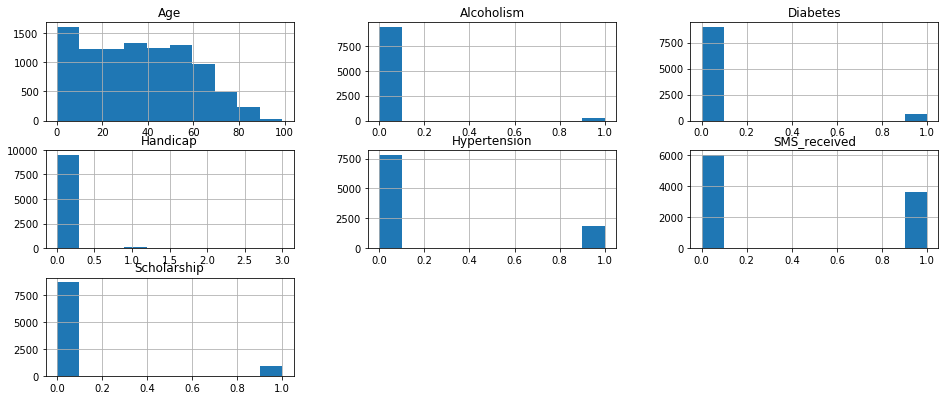

```python
df.hist(figsize=(16,6.5));
```

## Exploratory Data Analysis

Now that we've managed and cleaned the information, we'll continue on toward investigation. here we will Compute measurements and create visualizations with the aim of tending to the research questions presented in the Introduction segment.

### Research Question 1 (What is the level of patients who went to their arrangements against individuals who missed?)

```python
df.No_show.value_counts()
```

```
No     5721
Yes    3935
Name: No_show, dtype: int64
```

```python
total_patient_num = df.shape[0]
num_attendants = df.No_show.value_counts()["No"]
num_absents = df.No_show.value_counts()["Yes"]
```

|  | Absent |
| --- | --- |
| No | 5721 |
| Yes | 3935 |

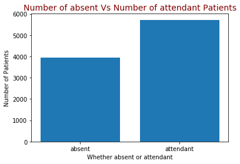

```python
plt.bar(["absent","attendant"],[num_absents, num_attendants])
plt.xlabel("Whether absent or attendant")
plt.ylabel("Number of Patients")
plt.title("Number of absent Vs Number of attendant Patients", color="maroon", fontsize=14);
df.No_show.value_counts().to_frame("Absent")
```

```python
# Divding the patients based on their show up to appointments

show=df.No_show=='No'
noshow=df.No_show=='Yes'
df[show].count(), df[noshow].count()
```

```
(Gender           5721
 Age              5721
 Neighbourhood    5721
 Scholarship      5721
 Hypertension     5721
 Diabetes         5721
 Alcoholism       5721
 Handicap         5721
 SMS_received     5721
 No_show          5721
 dtype: int64, Gender           3935
 Age              3935
 Neighbourhood    3935
 Scholarship      3935
 Hypertension     3935
 Diabetes         3935
 Alcoholism       3935
 Handicap         3935
 SMS_received     3935
 No_show          3935
 dtype: int64)
```

The number of showed patients is(5721) greather than the number of Non showed(3935)

```python
df[show].mean(),df[noshow].mean()
```

```
(Age             37.619997
 Scholarship      0.090019
 Hypertension     0.206957
 Diabetes         0.075861
 Alcoholism       0.023947
 Handicap         0.019577
 SMS_received     0.323020
 dtype: float64, Age             33.551461
 Scholarship      0.109022
 Hypertension     0.163659
 Diabetes         0.060991
 Alcoholism       0.031258
 Handicap         0.014231
 SMS_received     0.447268
 dtype: float64)
```

mean age for showed patients is 37.62, no showed is 33.6 patients gotten sms which implies we must have to change our sms campaign

### Research Question 2 (Who do go to the doctor more often, males or females?)

```python
df.Gender.value_counts()
```

```
F    6243
M    3413
Name: Gender, dtype: int64
```

```python
Female_prop = df.Gender.value_counts()[0] / df.shape[0]
Female_prop
```

```
0.6465410107705054
```

```python
Male_prop = df.Gender.value_counts()[1] / df.shape[0]
Male_prop
```

```
0.3534589892294946
```

```python
Male_prop = df.Gender.value_counts()[1] / df.shape[0]
Male_prop
```

```
0.3534589892294946
```

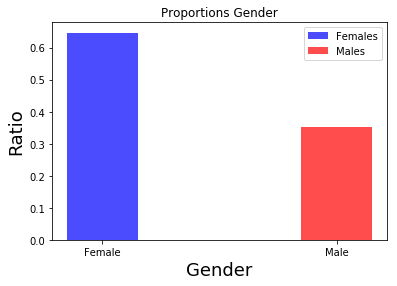

```python
Female_bar = plt.bar(0, Female_prop, width=.3, alpha=0.7, color ='blue', label='Females' )
Male_bar = plt.bar(1, Male_prop, width=.3, alpha=0.7, color='red', label='Males')

# title and labels
plt.xticks([0, 1], ['Female', 'Male'])
plt.xlabel('Gender', fontsize=18)
plt.ylabel('Ratio', fontsize=18)
plt.title('Proportions Gender');
plt.legend();
```

Proportion of people scheduled appointments are 65% Females and 35% Males

# Research Question 3 (Investigation for factors that affect attendance)

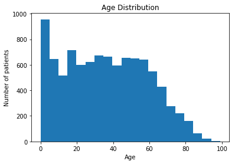

```python
# does patients age affect the attendance rate?

fig, ax = plt.subplots()
ax.hist(df['Age'], linewidth=0.5, bins=20)
ax.set_xlabel("Age")
ax.set_title('Age Distribution');
ax.set_ylabel('Number of patients');
```

In the above histogram, we notice that the most number of patients are kids. We now have to group the 'age_range' against 'No_show' section to see the relationship between's a patient's age and their capacity to go to an arrangement. See code cells beneath.

```python
range_labels = ['0-4', '5-9', '10-17', '18-32', '33-52', '53-75', '76+']
max_age = df.Age.max()
bins = [0, 4, 9, 17, 32, 52, 75, max_age]

age_range = pd.cut(df['Age'],labels=range_labels, bins=bins)
df.insert(7, 'age_range', age_range)
```

```python
df.columns
```

```
Index(['Gender', 'Age', 'Neighbourhood', 'Scholarship', 'Hypertension',
       'Diabetes', 'Alcoholism', 'age_range', 'Handicap', 'SMS_received',
       'No_show'],
      dtype='object')
```

```python
a = df.groupby(['age_range'])['No_show'].count() # Total count of selected columns values.
b = df.groupby(['age_range', 'No_show'])['No_show'].count() # Total count of selected columns values against patients who attended and those who missed.
c = b/a # Divide b by a to get the count of patients who attended and those who missed
```

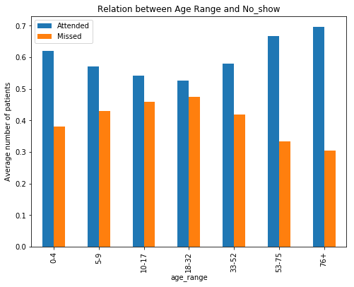

```python
c.unstack().plot(kind = 'bar', figsize = (8,6));
plt.title('Relation between Age Range and No_show')
plt.ylabel('Average number of patients')
plt.legend(['Attended','Missed']);
```

# Research Question 4 (Which age is most affected by disease (hypertension, diabetes, alcoholism, handicap)?

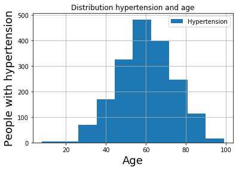

```python
# create a plot chart for the hipertesnion and age

df.Age[df.Hypertension == 1].hist(bins = 10, label = 'Hypertension' );
plt.title('Distribution hypertension and age')
plt.xlabel('Age', fontsize=18);
plt.ylabel('People with hypertension', fontsize=18);
plt.legend();
```

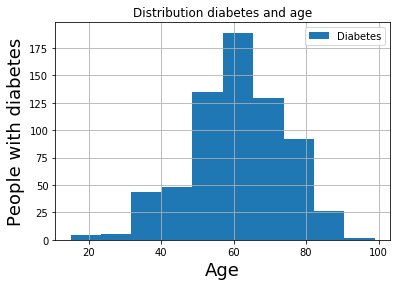

```python
# create a plot chart for the diabetes and age

df.Age[df.Diabetes == 1].hist(bins = 10, label = 'Diabetes' );
plt.title('Distribution diabetes and age')
plt.xlabel('Age', fontsize=18);
plt.ylabel('People with diabetes', fontsize=18);
plt.legend();
```

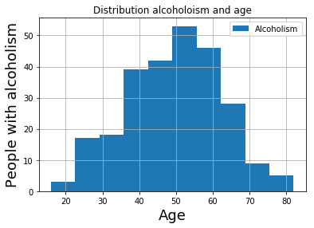

```python
# create a plot for the alcoholism and age

df.Age[df.Alcoholism == 1].hist(bins = 10, label = 'Alcoholism' );
plt.title('Distribution alcoholoism and age')
plt.xlabel('Age', fontsize=18);
plt.ylabel('People with alcoholism', fontsize=18);
plt.legend();
```

```python
df.columns
```

```
Index(['Gender', 'Age', 'Neighbourhood', 'Scholarship', 'Hypertension',
       'Diabetes', 'Alcoholism', 'age_range', 'Handicap', 'SMS_received',
       'No_show'],
      dtype='object')
```

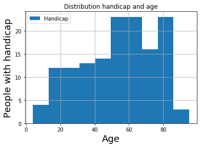

```python
# create a plot for the handicap and age

df.Age[df.Handicap == 1].hist(bins = 10, label = 'Handicap' );
plt.title('Distribution handicap and age')
plt.xlabel('Age', fontsize=18);
plt.ylabel('People with handicap', fontsize=18);
plt.legend();
```

# Research Question 5 (Does receiving SMS reminder affect patients attendance to appointments?)

```python
# grouping the sms_received and no_show columns for computing their percentages values
df.groupby('SMS_received').No_show.value_counts(normalize=True)
```

```
SMS_received  No_show
0             No         0.640377
              Yes        0.359623
1             No         0.512195
              Yes        0.487805
Name: No_show, dtype: float64
```

This is to say that about 64% of patients did not recieve sms, yet they made it to their appointments and about 51% of those who received an sms reminder also attended their appointments.

[figure not shown]

```python
sns.countplot(x=df['SMS_received'], hue=df['No_show']);
plt.title('SMS Received VS No SMS');
plt.xticks([0, 1], ['SMS', 'No SMS'], rotation=0);
plt.legend(['Attended','Missed']);
```

## Refrence

Ahmad Elsaway on Github

```python
from subprocess import call
call(['python', '-m', 'nbconvert', 'Investigate_a_Dataset.ipynb'])
```

```
0
```